# Milestone Report

Jie Tao

10/10/2020

# 1 Milestone Report

## 1.1 Summary

The goal of this project is to show the the exploratory analysis of the three text data sets, which are blog, twitter, and news data. By explaining the descriptive statistics and visualizing the data, this analysis builds the foundation for building prediction algorithm and Shiny app later on. The descriptive statistics and data visualization include unigram, bigrams, and trigrams.

## 1.2 Read Data

The first step is to read all three data sets. Since the size of the data is huge, I decided to subset the data by random sampling.

```r
blog <- read_lines(file = "E:/Data Science Specialization/Data Science Capstone/final/en_US/en_US.blogs.txt", skip_empty_rows = TRUE)
twitter <- read_lines(file = "E:/Data Science Specialization/Data Science Capstone/final/en_US/en_US.twitter.txt", skip_empty_rows = TRUE)
news <- read_lines(file = "E:/Data Science Specialization/Data Science Capstone/final/en_US/en_US.news.txt", skip_empty_rows = TRUE)
```

## 1.3 Sample Data

I randomly sampled 5% of the lines in each data set.

```r
set.seed(456)
blog <- sample(blog, size = length(blog)*0.05)
twitter <- sample(twitter, size = length(twitter)*0.05)
news <- sample(news, size = length(news)*0.05)
```

## 1.4 Build Data Frames

The sampled data sets were then combined into one dataframe.

```r
blog_df <- as_tibble(blog) %>%
    transmute(document = "blog", text = value)
twitter_df <- as_tibble(twitter) %>%
    transmute(document = "twitter", text = value)
news_df <- as_tibble(news) %>%
    transmute(document = "news", text = value)
df <- bind_rows(blog_df, twitter_df, news_df)
```

## 1.5 Exploratory Analysis of Unigram

### 1.5.1 Tokenization

The first strategy used the tokenize the text is by unigram (or single word). After tokenization, I further filtered out stopwords, all numbers, and “rt” stands for retweet.

```r
# tokenization
tidy_df <- df %>%
    unnest_tokens(word, text, token = "words")

# remove stop words
tidy_df <- tidy_df %>%
    filter(!word %in% stopwords(source = "stopwords-iso"),
           !word %in% str_extract_all(word, "[:digit:]+"),
           !word %in% str_extract_all(word, "rt"))
```

### 1.5.2 Word Cloud for Unigram

A word cloud was created to show the most frequently used words, the top 5 of which are “time”, “day”, “love”, “people”, and “life”.

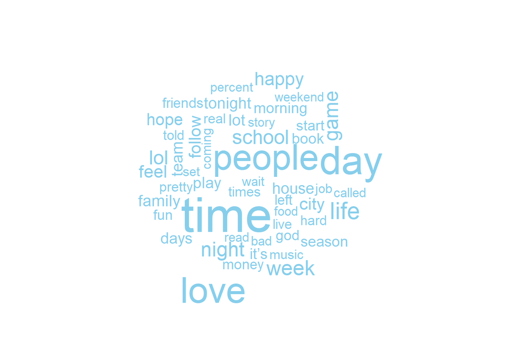

```r
# wordcloud unigram
tidy_df %>%
    count(word) %>%
    with(wordcloud(word, n, max.words = 50, colors = "skyblue"))
```

### 1.5.3 Barplot of Unigram Fequency by Type

Then, I grouped the data by their sources and plotted three bar charts, which show that some words were used frequently across different sources such as “time”, “people”, and “day”; whereas other words are relatively unique to each source such as “follow” for words from tweets and “game” for news data.

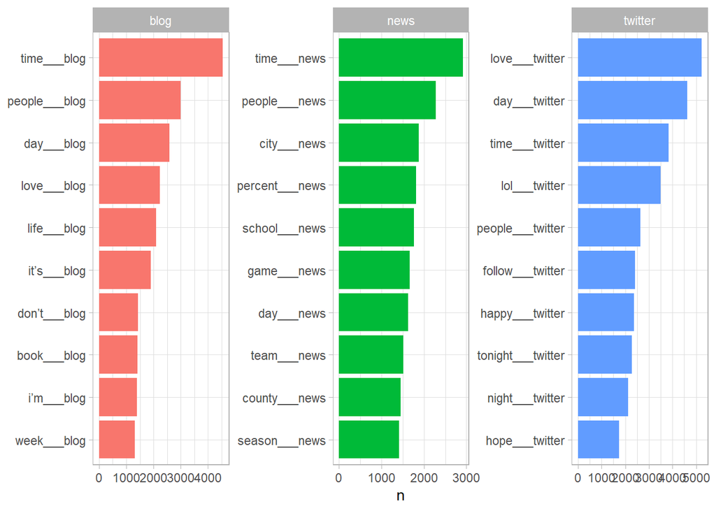

```r
# frequency of unigram by type
tidy_df %>%
    group_by(document) %>%
    count(word, sort = TRUE) %>%
    slice_max(n, n = 10) %>%
    ungroup() %>%
    mutate(word = reorder_within(word, n, document)) %>%
    ggplot(aes(word, n, fill = document)) +
    geom_col(show.legend = FALSE) +
    facet_wrap(~document, scales = "free")+
    xlab(NULL)+
    coord_flip()
```

## 1.6 Exploratory Analysis of Bigrams

### 1.6.1 Tokenization

The second approach to tokenize data is to construct bigrams (i.e., two consecutive words).

```r
tidy_bigrams <- df %>%
    unnest_tokens(bigram, text, token = "ngrams", n = 2) %>%
    separate(col = bigram, into = c("word1", "word2"), sep = " ") %>%
    filter(!word1 %in% stopwords(source = "stopwords-iso"),
           !word1 %in% str_extract_all(word1, "[:digit:]+"),
           !word1 %in% str_extract_all(word1, "rt"),
           !word2 %in% stopwords(source = "stopwords-iso"),
           !word2 %in% str_extract_all(word2, "[:digit:]+"),
           !word2 %in% str_extract_all(word2, "rt")) %>%
    unite(bigram, word1, word2, sep = " ")
```

### 1.6.2 Word Cloud for Bigrams

As shown in the word cloud, the three most frequently used bigrams are “happy birthday”, “los angeles”, and “san francisco”.

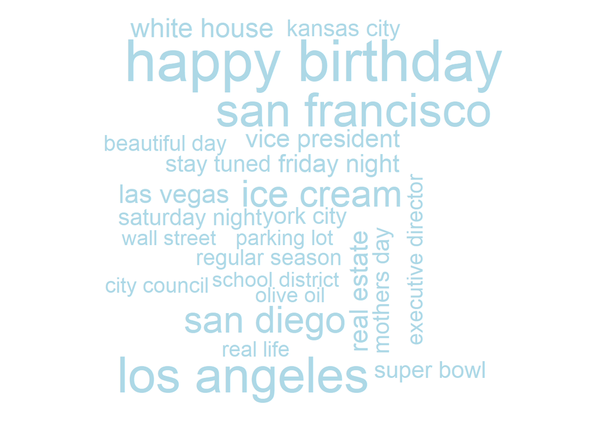

```r
# wordcloud bigrams
tidy_bigrams %>%
    count(bigram) %>%
    with(wordcloud(bigram, n, max.words = 30, colors = "lightblue"))
```

### 1.6.3 Bigrams Network

The bigrams network shows the relationships among two consecutive words in terms of their direction and frequency. For example, the bigram “los angeles” starts from “los” and ends at “angeles” and the frequency is relatively high due to darker color.

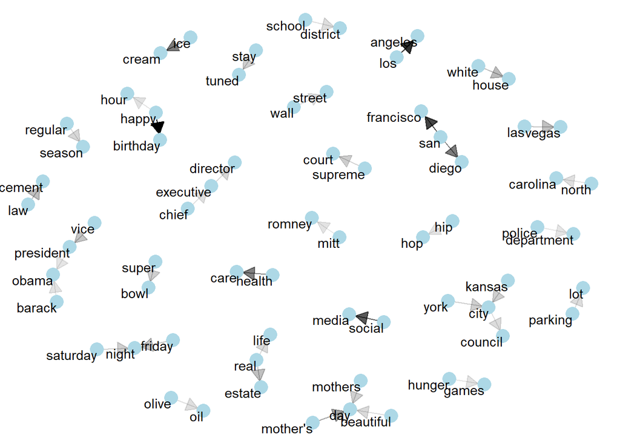

```r
# bigrams network
bigram_graph <- tidy_bigrams %>%
    separate(col = bigram, into = c("word1", "word2"), sep = " ") %>%
    count(word1, word2) %>%
    filter(n > 100) %>%
    graph_from_data_frame()

set.seed(2016)

a <- grid::arrow(type = "closed", length = unit(.15, "inches"))

ggraph(bigram_graph, layout = "fr") +
  geom_edge_link(aes(edge_alpha = n), show.legend = FALSE,
                 arrow = a, end_cap = circle(.07, 'inches')) +
  geom_node_point(color = "lightblue", size = 5) +
  geom_node_text(aes(label = name), vjust = 1, hjust = 1) +
  theme_void()
```

### 1.6.4 Barplot for Frequency of Bigrams by Type

The barplot further breaks the data into groups and displays that “ice cream”, “los angeles”, and “happy birthday” are the most mentioned words in blog, news, and twitter data sets respectively.

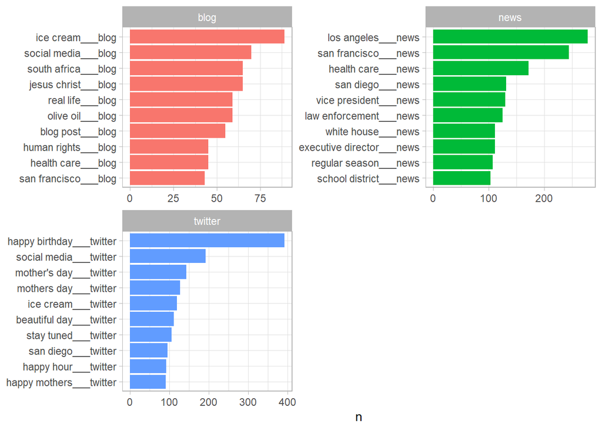

```r
# frequency of bigrams by type
tidy_bigrams %>%
    group_by(document) %>%
    count(bigram, sort = TRUE) %>%
    slice_max(n, n = 10) %>%
    ungroup() %>%
    mutate(bigram = reorder_within(bigram, n, document)) %>%
    ggplot(aes(bigram, n, fill = document)) +
    geom_col(show.legend = FALSE) +
    facet_wrap(~document, scales = "free", nrow = 2)+
    xlab(NULL)+
    coord_flip()
```

## 1.7 Exploratory Analysis of Trigrams

### 1.7.1 Tokenization

Trigram is the last method used to tokenize.

```r
tidy_trigrams <- df %>%
    unnest_tokens(trigram, text, token = "ngrams", n = 3) %>%
    separate(col = trigram, into = c("word1", "word2", "word3"), sep = " ") %>%
    filter(!word1 %in% stopwords(source = "stopwords-iso"),
           !word1 %in% str_extract_all(word1, "[:digit:]+"),
           !word1 %in% str_extract_all(word1, "rt"),
           !word2 %in% stopwords(source = "stopwords-iso"),
           !word2 %in% str_extract_all(word2, "[:digit:]+"),
           !word2 %in% str_extract_all(word2, "rt"),
           !word3 %in% stopwords(source = "stopwords-iso"),
           !word3 %in% str_extract_all(word3, "[:digit:]+"),
           !word3 %in% str_extract_all(word3, "rt")) %>%
    unite(trigram, word1, word2, word3, sep = " ")
```

### 1.7.2 Word Cloud for Trigrams

The top three most used trigrams are “happy mothers day”, “happy mother’s day”, and “president barack obama”.

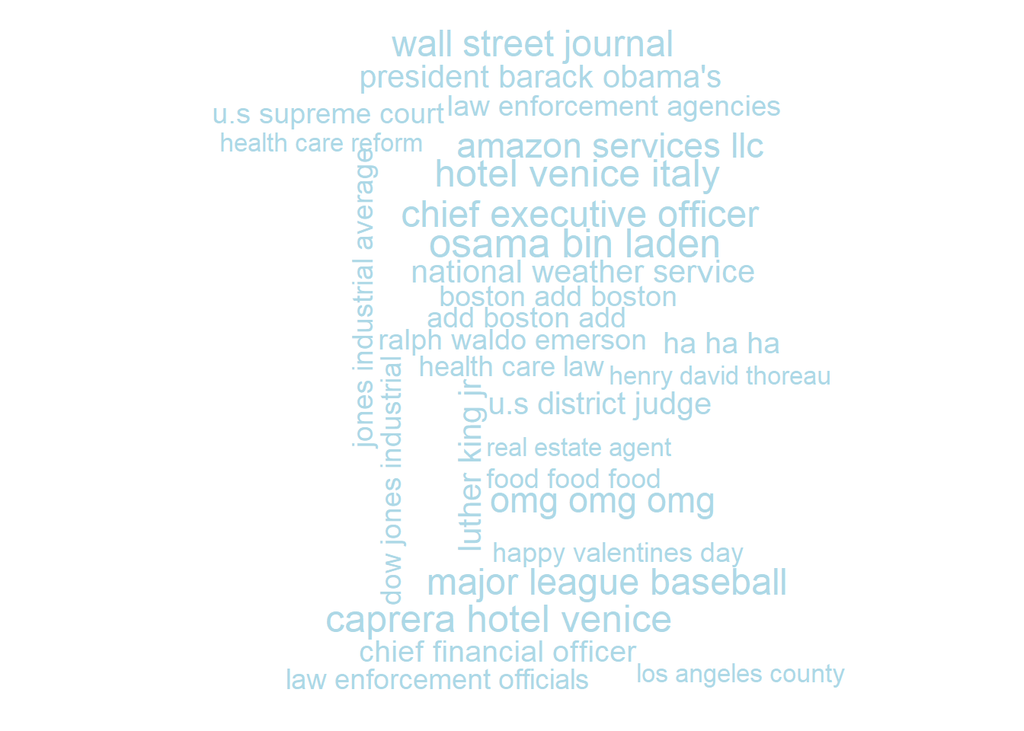

```r
# wordcloud trigrams
tidy_trigrams %>%
    count(trigram) %>%
    with(wordcloud(trigram, n, max.words = 40, colors = "lightblue"))
```

### 1.7.3 Trigrams Network

It is clear in the chart that there are two major networks clustered around “happy” and “president”.

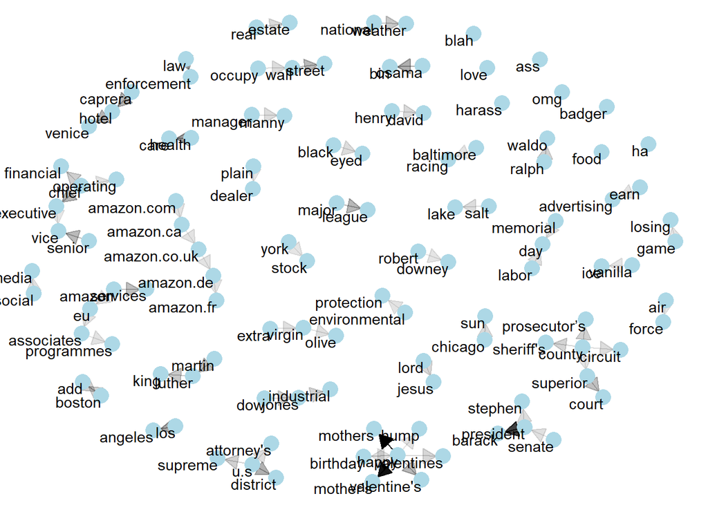

```r
# trigrams network
trigram_graph <- tidy_trigrams %>%
    separate(col = trigram, into = c("word1", "word2", "word3"), sep = " ") %>%
    count(word1, word2, word3) %>%
    filter(n > 10) %>%
    graph_from_data_frame()

set.seed(678)

a <- grid::arrow(type = "closed", length = unit(.15, "inches"))

ggraph(trigram_graph, layout = "fr") +
  geom_edge_link(aes(edge_alpha = n), show.legend = FALSE,
                 arrow = a, end_cap = circle(.07, 'inches')) +
  geom_node_point(color = "lightblue", size = 5) +
  geom_node_text(aes(label = name), vjust = 1, hjust = 1) +
  theme_void()
```

### 1.7.4 Barplot for Frequency of Trigrams by Type

The most frequent words in the barplot by their sources are “hotel venice italy”, “president barack obama”, and “happy mothers day”.

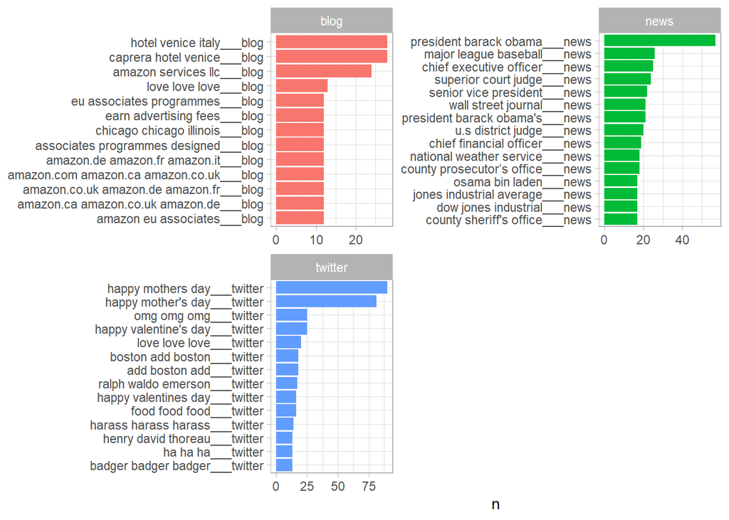

```r
# frequency of trigrams by type
tidy_trigrams %>%
    group_by(document) %>%
    count(trigram, sort = TRUE) %>%
    slice_max(n, n = 13) %>%
    ungroup() %>%
    mutate(trigram = reorder_within(trigram, n, document)) %>%
    ggplot(aes(trigram, n, fill = document)) +
    geom_col(show.legend = FALSE) +
    facet_wrap(~document, scales = "free", nrow = 2)+
    xlab(NULL)+
    coord_flip()
```

## 1.8 Conlusion

It it clear that the different tokenization methods generate varied sets of frequently used words. Thus, building the prediction algorithm based on either bigram or trigram is the first important decision to make.